# GSFA Results of CD8+ T Cell CROP-seq Data

-- for manuscript

Yifan Zhou (zhouyf@uchicago.edu)

2022-02

# 1 Background

## 1.1 Input data and pre-processing

Source:  
[Genome-wide CRISPR Screens in Primary Human T Cells Reveal Key Regulators of Immune Function](https://www.ncbi.nlm.nih.gov/pmc/articles/PMC6689405/), GEO accession: GSE119450.

Perturbations:  
CRISPR knock-out of 20 genes (2 gRNAs per gene) + 8 non-targeting gRNAs. Guide conditions were defined on the target gene level; target genes were either found to regulate T cell responses in the genome-wide screens, or known checkpoint genes.  
Guide RNAs were introduced into T cells through a novel procedure called sgRNA lentiviral infection with Cas9 protein electroporation (SLICE).

Genes:  
**Top 6000 genes ranked by the multinomial deviance statistics were kept.**

Normalization:  
Deviance residual transformation.  
**Donor batch was not corrected for.**  
**Unique UMI count, library size, and mitochondria percentage were all corrected for. The corrected and scaled expression data were used as input for subsequent GSFA.**

## 1.2 GSFA

Input:  
In addition to the expression matrix, we have a binary perturbation matrix ($G$) consisting of 21 types (20 genes + negative control) of gene-level KO conditions across cells.

For Gibbs sampling, we specified 20 factors initialized from truncated SVD. Results were obtained from 4000 iterations, with the posterior mean estimates averaged over the last 1000 iterations.

The association of $Z$ with $G$ were estimated separately for stimulated and unstimulated cells, generating two effect size matrices, $\beta_1$ and $\beta_0$, and two $LFSR$ matrices that summarized the effects of perturbations on genes for stimulated and unstimulated cells, respectively.

# 2 Factor ~ Perturbation Associations

## 2.1 Perturbation effects on factors ($\beta$) (stimulated cells)

All targets and factors (Figure S4A):

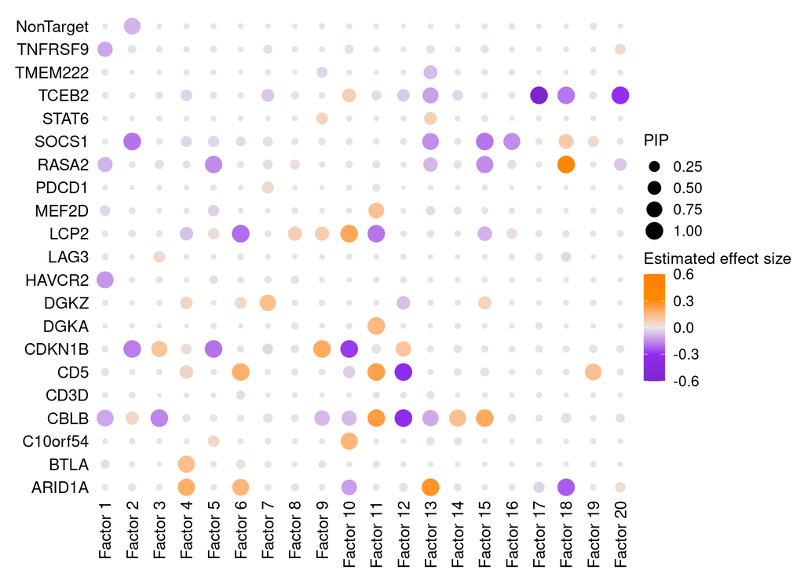

Effects of selected perturbations on factors (Figure 3A):

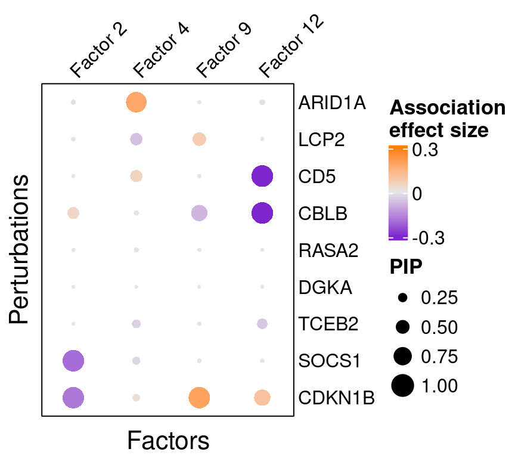

## 2.2 Factor-perturbation association p values (stimulated cells)

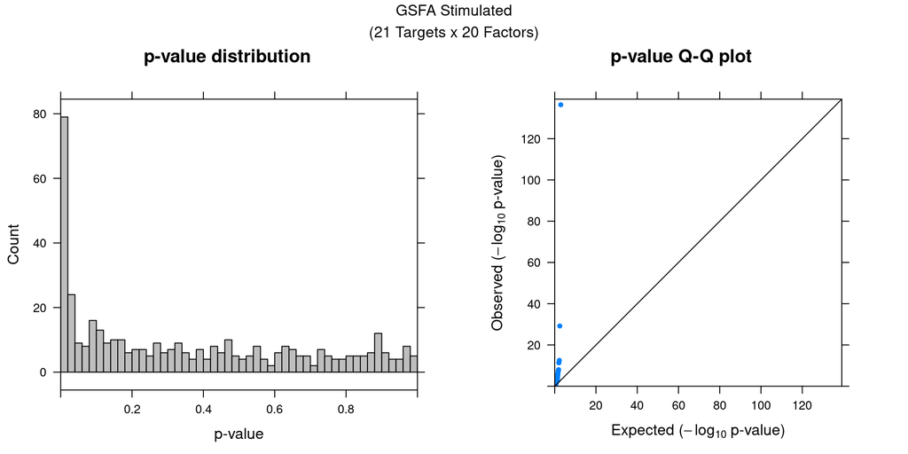

## 2.3 Perturbation effects on factors ($\beta$) (unstimulated cells)

All targets and factors (Figure S4B):

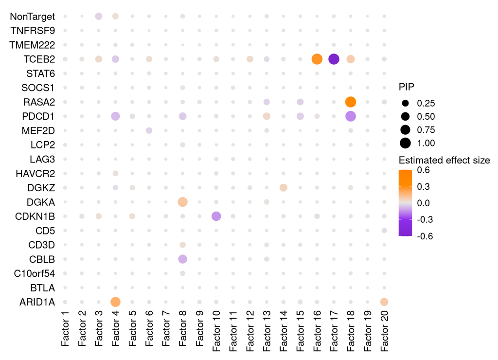

# 3 Factor Interpretation

## 3.1 Correlation within factors

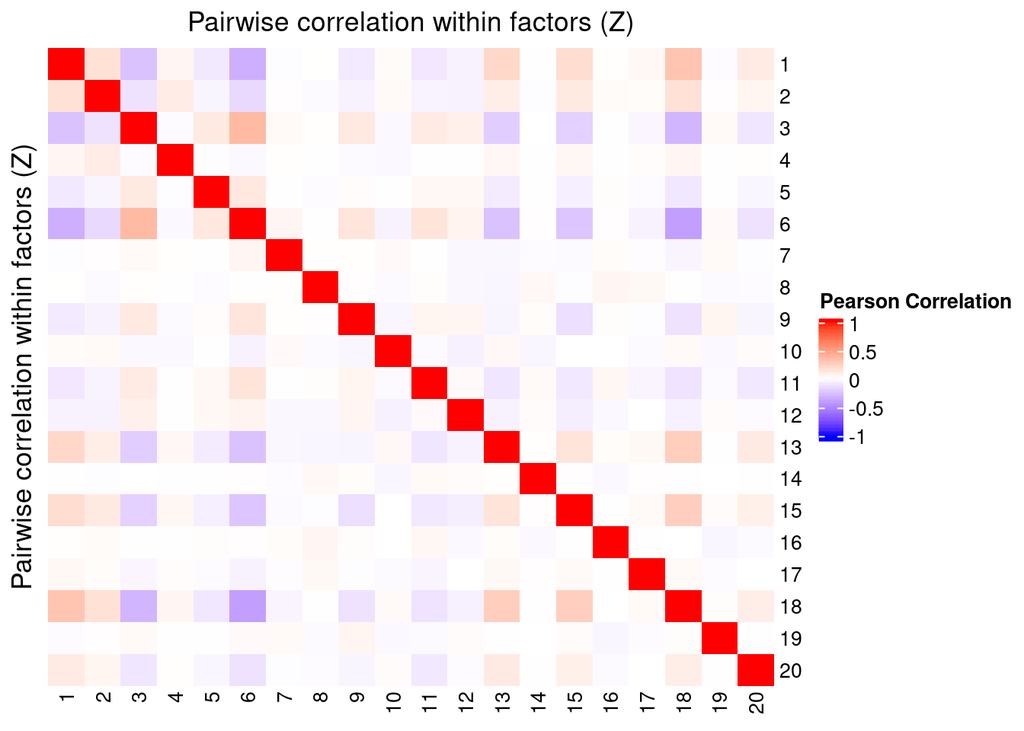

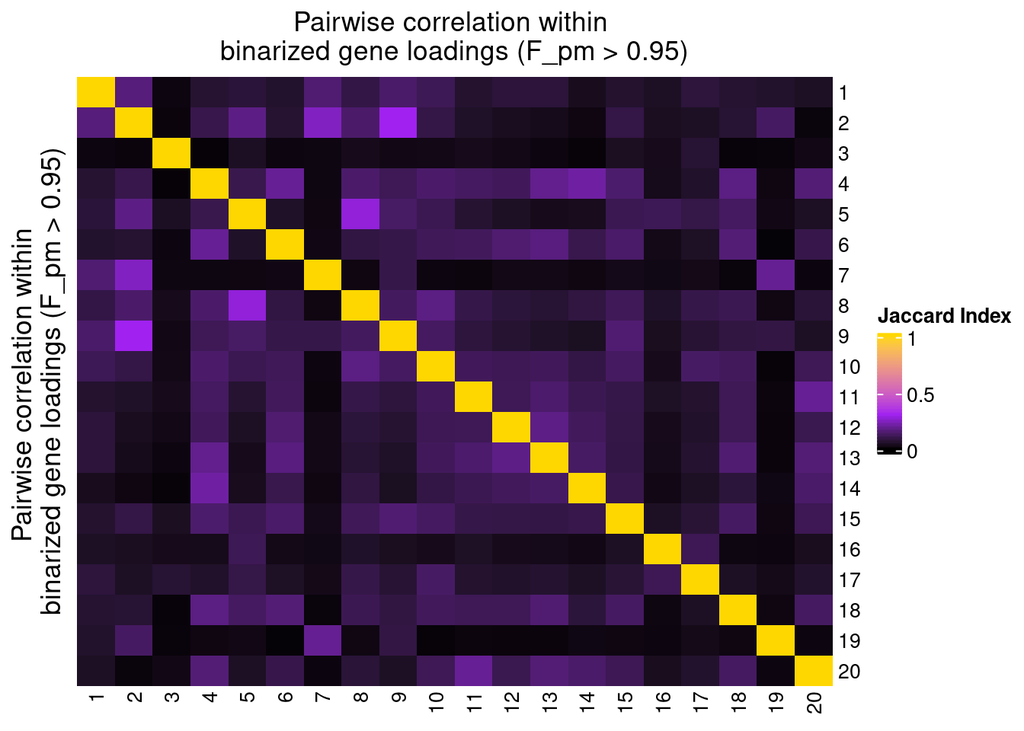

## 3.2 Gene loading in factors

T cell markers:

| gene_name | type | protein_name | gene_ID |
| --- | --- | --- | --- |
| IL7R | T cell resting state | IL-7 receptor | ENSG00000168685 |
| CCR7 | T cell resting state | C-C motif chemokine receptor 7 | ENSG00000126353 |
| GZMB | T cell activation | Granzyme B | ENSG00000100453 |
| IFNG | T cell activation | Interferon gamma | ENSG00000111537 |
| CD44 | T cell activation | CD44 | ENSG00000026508 |
| IL2RA | T cell activation | IL-2 receptor | ENSG00000134460 |
| XCL1 | T cell activation | X-C motif chemokine ligand 1 | ENSG00000143184 |
| TNFRSF18 | T cell activation | GITR | ENSG00000186891 |
| ITGAL | T cell activation | LFA-1 | ENSG00000005844 |
| MKI67 | Cell proliferation | Marker of proliferation Ki-67 | ENSG00000148773 |
| TOP2A | Cell proliferation | DNA topoisomerase II alpha | ENSG00000131747 |
| CENPF | Cell proliferation | Centromere protein F | ENSG00000117724 |

All factors (Figure S4C):

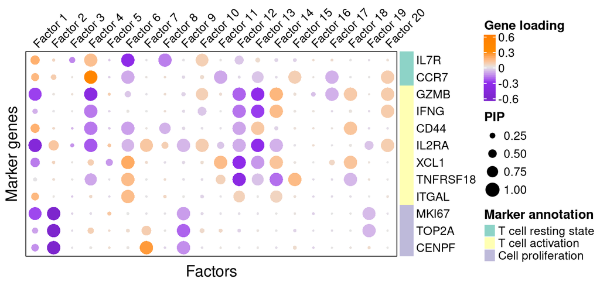

Selected factors (Figure 3C):

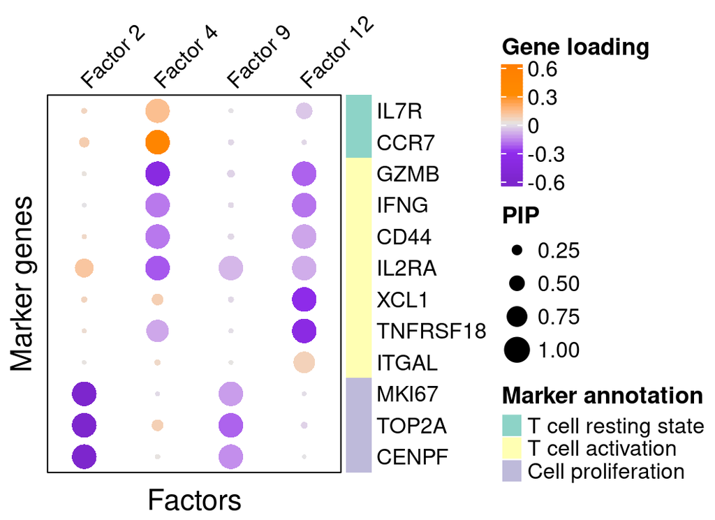

## 3.3 GO enrichment analysis in factors

Foreground genes: Genes w/ non-zero loadings in each factor (gene PIP > 0.95);  
Background genes: all 6000 genes used in GSFA;  
Statistical test: hypergeometric test (over-representation test);  
Gene sets: Gene ontology "Biological Process" (non-redundant).

Figure 3D:

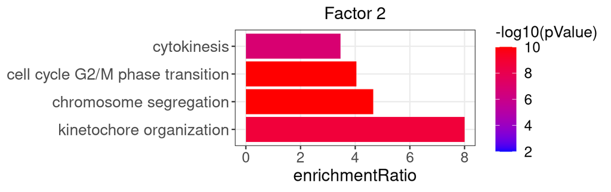

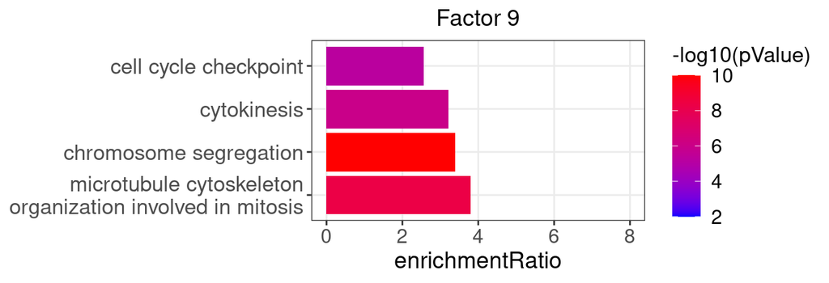

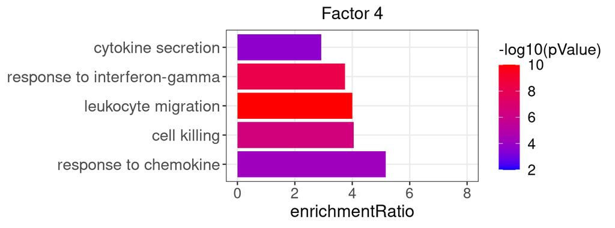

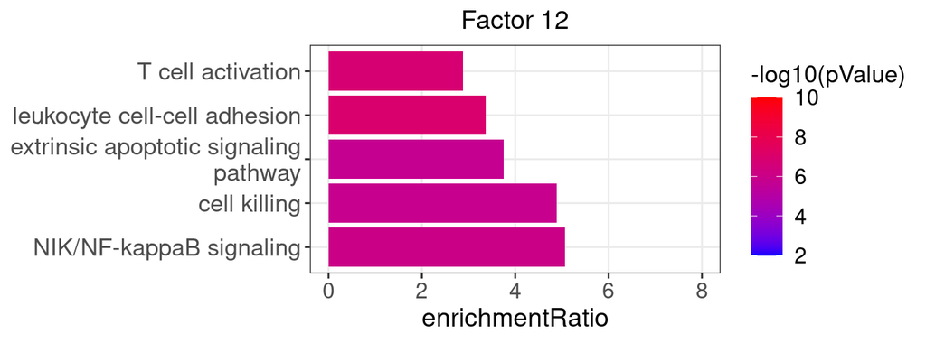

# 4 DEG Interpretation

**Here, we compared the DEG results within stimulated cells.**

## 4.1 Number of DEGs detected by different methods

Number of DEGs detected by GSFA:

| KO | ARID1A | BTLA | C10orf54 | CBLB | CD3D | CD5 | CDKN1B |
| --- | --- | --- | --- | --- | --- | --- | --- |
| Num_genes | 448 | 0 | 0 | 481 | 0 | 586 | 710 |
| KO | DGKA | DGKZ | HAVCR2 | LAG3 | LCP2 | MEF2D | NonTarget |
| Num_genes | 148 | 0 | 0 | 0 | 586 | 0 | 0 |
| KO | PDCD1 | RASA2 | SOCS1 | STAT6 | TCEB2 | TMEM222 | TNFRSF9 |
| Num_genes | 0 | 271 | 511 | 0 | 240 | 0 | 0 |

Figure 4A:

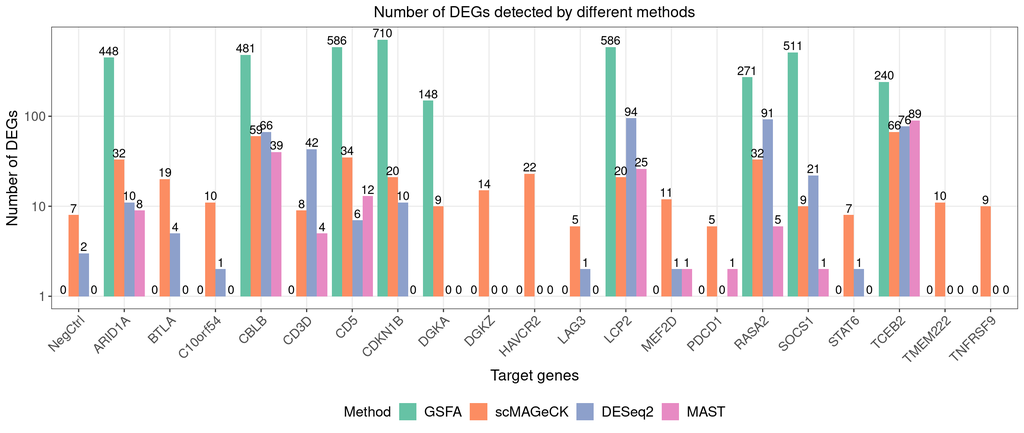

## 4.2 Perturbation effects on marker genes

### 4.2.1 GSFA

Figure 4D:

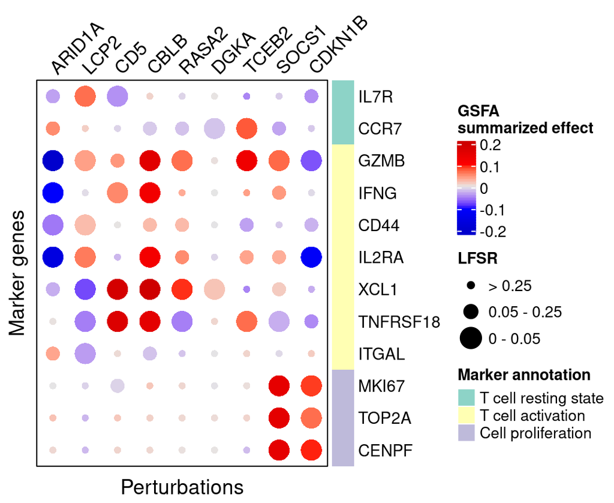

### 4.2.2 scMAGeCK

Figure 4E:

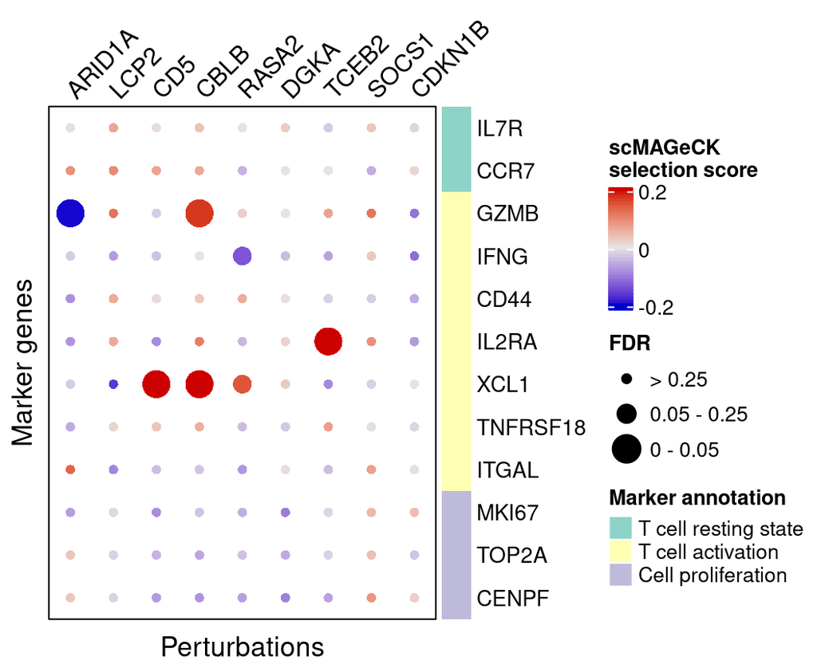

### 4.2.3 DESeq2

Figure S4D:

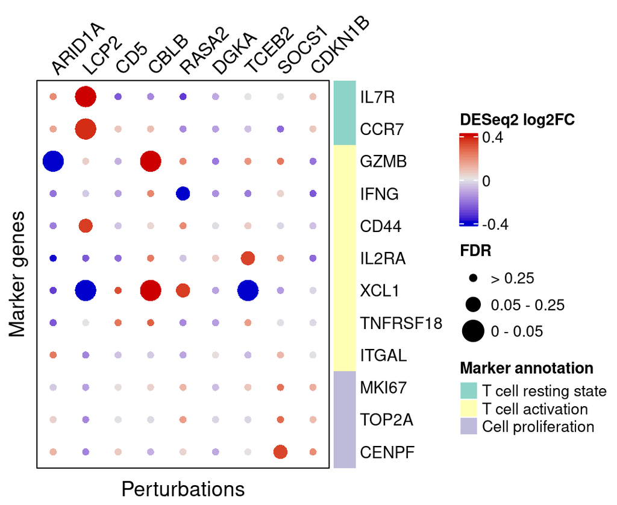

### 4.2.4 MAST

Figure S4E:

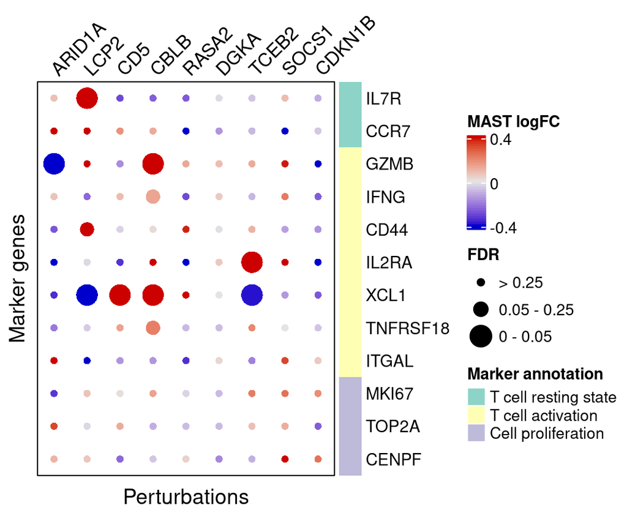

## 4.3 GO enrichment in DEGs

Foreground genes: Genes w/ GSFA LFSR < 0.05 under each perturbation;  
Background genes: all 6000 genes used in GSFA;  
Statistical test: hypergeometric test (over-representation test);  
Gene sets: Gene ontology "Biological Process" (non-redundant).

Figure 4C:

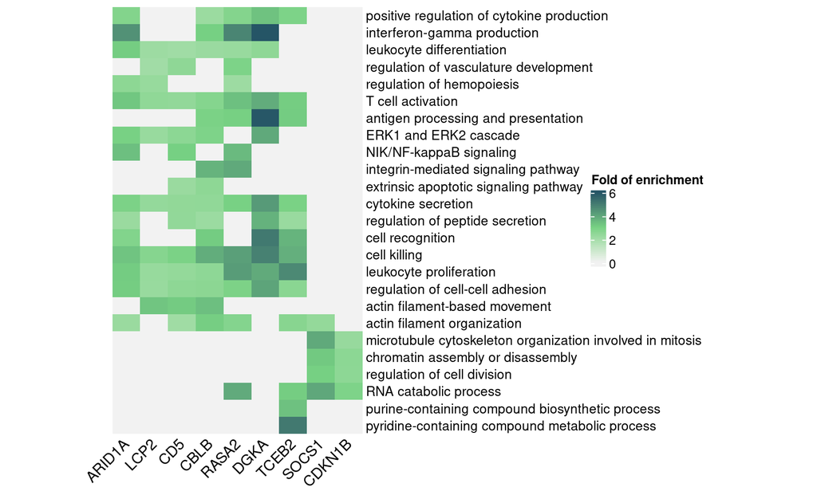